# M2020 dia a dia

### qqplot de normalitat per les notes de les PAAU

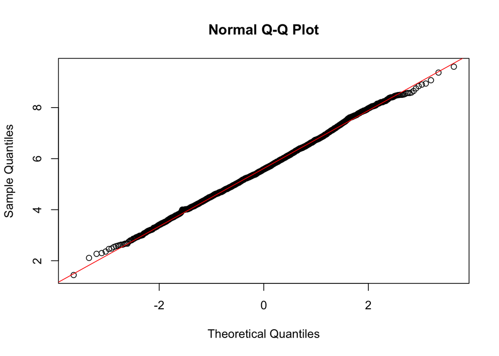

```r
 qqnorm(data$PAAU)
 qqline(data$PAAU, col="red")
```

### la mateixa distribució normal: dades simulades

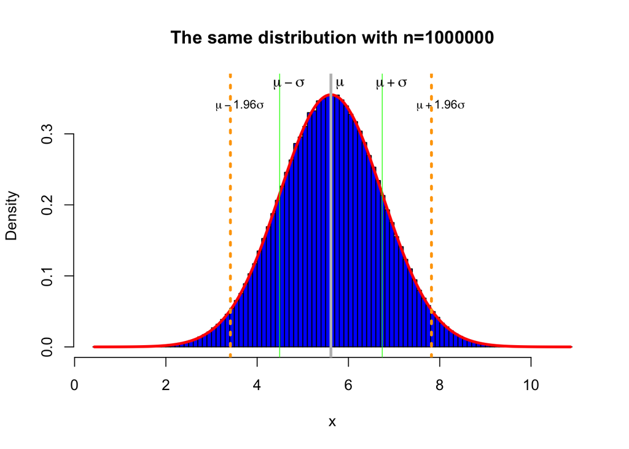

```r
set.seed(291114)
 n<-1000000
x<- rnorm(n,     5.616312, 1.123641)
 hist(x,  prob=T, 100, col="blue", main = "The same distribution with n=1000000", ylim=c(0,.37))
   # lines(density(PAAU), col="green")
 ra<- seq(min(x), max(x),length=300)
 lines(ra,dnorm(ra, mean=mean(x), sd=sd(x)), col="red", lwd=3 )
 abline(v = 5.616312, col="grey", lwd=3)
  abline(v = 5.616312-1.123641, col="green", lwd=.8)
    abline(v = 5.616312+1.123641, col="green", lwd=.8)
     text(5.616312+.2,0.37, expression(mu))
         text(5.616312-1.123641 +.2,0.37, expression(mu-sigma))
           text(5.616312+1.123641 +.2,0.37, expression(mu+sigma))

               abline(v = (5.616312+1.96*1.123641), col="orange", lwd=3, lty=3)
                     abline(v = (5.616312-1.96*1.123641), col="orange", lwd=3, lty=3)
            text(5.616312- 1.96*1.123641 +.2,0.34, expression(mu-1.96*sigma), cex=.8)
           text(5.616312+1.96*1.123641 +.2,0.34, expression(mu+1.96*sigma),cex=.8)
```

L’interval $\mu \pm 1.96\sigma$ agafa el 95% dels valors de la variable ($\mu \pm 2\sigma$ agafa el 95.5% ); per agafar el 99%, cal l’interval $\mu \pm 2.56\sigma$.

The important result here is that 95% of values from a Normal Distribution tall within 1.96 standard deviatios fo the mean. We can also show that 99% of vlaues from a Normal Distribution fall within 2.58 standard deviations of rthe mean. We will use both of these results later in the course.

## Problema:

1. Percentil de l’estudiant amb nota 6.8. Quin % d’estudiants queden per sobre?
2. Calculeu el % d’estudiants amb nota entre 6 i 8
3. % d’estudiants and nota per sota de 4